# Exam 1 Output Packet

The goal of this analysis is to predict whether a person’s income was large (defined as more than $50k) or small. The predictors include: age, workclass, education, education-num (number of years someone was in school), marital-status, occupation, relationship, race, sex, capital-gain, capital-loss, hours-per-week, native-country. The data was obtained from census data.

```
## 'data.frame':    30162 obs. of  14 variables:
##  $ age           : int  39 50 38 53 28 37 49 52 31 42 ...
##  $ workclass     : Factor w/ 8 levels "Federal-gov",..: 7 6 4 4 4 4 4 6 4 4 ...
##  $ education     : Ord.factor w/ 16 levels "Preschool"<"1st-4th"<..: 14 14 9 7 14 15 5 9 15 14 ...
##  $ education-num : int  13 13 9 7 13 14 5 9 14 13 ...
##  $ marital-status: Factor w/ 7 levels "Divorced","Married-AF-spouse",..: 5 3 1 3 3 3 4 3 5 3 ...
##  $ occupation    : Factor w/ 14 levels "Adm-clerical",..: 1 4 6 6 10 4 8 4 10 4 ...
##  $ relationship  : Factor w/ 6 levels "Husband","Not-in-family",..: 2 1 2 1 6 6 2 1 2 1 ...
##  $ race          : Factor w/ 5 levels "Amer-Indian-Eskimo",..: 5 5 5 3 3 5 3 5 5 5 ...
##  $ sex           : Factor w/ 2 levels "Female","Male": 2 2 2 2 1 1 1 2 1 2 ...
##  $ capital-gain  : int  2174 0 0 0 0 0 0 0 14084 5178 ...
##  $ capital-loss  : int  0 0 0 0 0 0 0 0 0 0 ...
##  $ hours-per-week: int  40 13 40 40 40 40 16 45 50 40 ...
##  $ native-country: Factor w/ 41 levels "Cambodia","Canada",..: 39 39 39 39 5 39 23 39 39 39 ...
##  $ income        : Ord.factor w/ 2 levels "small"<"large": 1 1 1 1 1 1 1 2 2 2 ...
```

## Data Summary

Here is a summary of the target variable.

```r
prop.table(table(df$income))
```

```
##
##      small      large
## 0.95772385 0.04227615
```

Here is a summary of the data:

```
##                      mean          sd min   max median length missing
## age             36.912235   13.407446  17    90     35  23654       0
## education-num    9.709478    2.441481   1    16      9  23654       0
## capital-gain   293.911305 2988.602381   0 99999      0  23654       0
## capital-loss    59.819227  329.257066   0  4356      0  23654       0
## hours-per-week  39.625814   11.971218   1    99     40  23654       0
##                levels          mode missing
## workclass           8       Private       0
## education          16       HS-grad       0
## marital-status      7 Never-married       0
## occupation         14  Adm-clerical       0
## relationship        6       Husband       0
## race                5         White       0
## sex                 2          Male       0
## native-country     41 United-States       0
## income              2         small       0
```

## Part 1 Modeling

### Data Preperation

```r
table(df$education, df$`education-num`)
```

```
##
##                   1    2    3    4    5    6    7    8    9   10   11   12   13
##   Preschool      45    0    0    0    0    0    0    0    0    0    0    0    0
##   1st-4th         0  146    0    0    0    0    0    0    0    0    0    0    0
##   5th-6th         0    0  278    0    0    0    0    0    0    0    0    0    0
##   7th-8th         0    0    0  527    0    0    0    0    0    0    0    0    0
##   9th             0    0    0    0  432    0    0    0    0    0    0    0    0
##   10th            0    0    0    0    0  769    0    0    0    0    0    0    0
##   11th            0    0    0    0    0    0  997    0    0    0    0    0    0
##   12th            0    0    0    0    0    0    0  351    0    0    0    0    0
##   HS-grad         0    0    0    0    0    0    0    0 8468    0    0    0    0
##   Prof-school     0    0    0    0    0    0    0    0    0    0    0    0    0
##   Assoc-acdm      0    0    0    0    0    0    0    0    0    0    0  796    0
##   Assoc-voc       0    0    0    0    0    0    0    0    0    0 1008    0    0
##   Some-college    0    0    0    0    0    0    0    0    0 5494    0    0    0
##   Bachelors       0    0    0    0    0    0    0    0    0    0    0    0 3208
##   Masters         0    0    0    0    0    0    0    0    0    0    0    0    0
##   Doctorate       0    0    0    0    0    0    0    0    0    0    0    0    0
##
##                  14   15   16
##   Preschool       0    0    0
##   1st-4th         0    0    0
##   5th-6th         0    0    0
##   7th-8th         0    0    0
##   9th             0    0    0
##   10th            0    0    0
##   11th            0    0    0
##   12th            0    0    0
##   HS-grad         0    0    0
##   Prof-school     0  188    0
##   Assoc-acdm      0    0    0
##   Assoc-voc       0    0    0
##   Some-college    0    0    0
##   Bachelors       0    0    0
##   Masters       820    0    0
##   Doctorate       0    0  127
```

Here is a summary of the native-country variable.

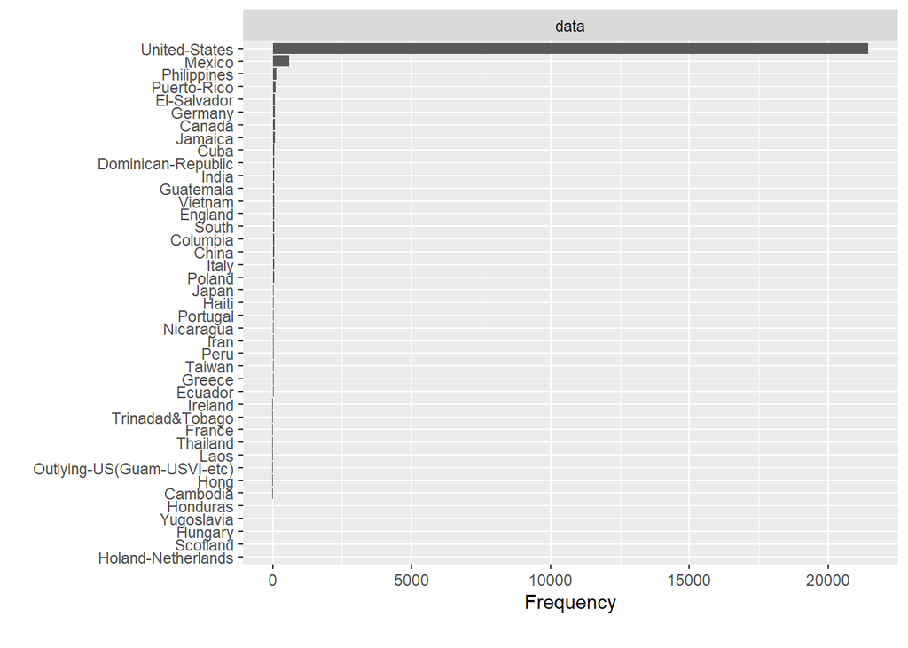

```r
library(DataExplorer)
plot_bar(df$`native-country`)
```

Summary of `marital-status_Married-AF-spouse`.

```r
summary(df$`marital-status_Married-AF-spouse`)
```

```
##     0     1
## 23643    11
```

### Partitioning and Over-Sampling

Here are the proportions for the validation data set.

```r
prop.table(table(valid$income))
```

```
##
##      small      large
## 0.95857113 0.04142887
```

```r
dim(valid)
```

```
## [1] 4731   38
```

Here are the proportions for the training data set.

```r
prop.table(table(training$income))
```

```
##
## small large
##   0.5   0.5
```

```r
dim(training)
```

```
## [1] 1608   38
```

### Modeling

#### Model 1

I constructed a full logistic model.

```r
reg<-glm(income~., data=training, family="binomial")
```

#### Model 2

And a reduced logistic a reduced model.

```r
reg2<-glm(income ~ `marital-status_Married-civ-spouse` +
    `education-num` + `capital-gain` + `hours-per-week` + age +
    relationship_Wife + `relationship_Own-child` + `capital-loss` +
    `occupation_Farming-fishing` + `occupation_Tech-support` +
    `occupation_Exec-managerial` + sex + `occupation_Prof-specialty` +
    occupation_Sales + `workclass_Self-emp-not-inc` + `marital-status_Never-married`,
    family = "binomial", data = training)
options(scipen = 999)
summary(reg2)
```

```
##
## Call:
## glm(formula = income ~ `marital-status_Married-civ-spouse` +
##     `education-num` + `capital-gain` + `hours-per-week` + age +
##     relationship_Wife + `relationship_Own-child` + `capital-loss` +
##     `occupation_Farming-fishing` + `occupation_Tech-support` +
##     `occupation_Exec-managerial` + sex + `occupation_Prof-specialty` +
##     occupation_Sales + `workclass_Self-emp-not-inc` + `marital-status_Never-married`,
##     family = "binomial", data = training)
##
## Deviance Residuals:
##     Min       1Q   Median       3Q      Max
## -3.4627  -0.5310  -0.0120   0.5932   2.5915
##
## Coefficients:
##                                         Estimate  Std. Error z value
## (Intercept)                          -8.22826924  0.65176687 -12.625
## `marital-status_Married-civ-spouse`1  1.88428211  0.24524785   7.683
## `education-num`                       0.28217610  0.03593722   7.852
## `capital-gain`                        0.00030195  0.00004897   6.166
## `hours-per-week`                      0.03771008  0.00719035   5.245
## age                                   0.02466935  0.00664711   3.711
## relationship_Wife                     1.87624505  0.39571886   4.741
## `relationship_Own-child`             -2.02877161  0.65897167  -3.079
## `capital-loss`                        0.00058585  0.00018909   3.098
## `occupation_Farming-fishing`1        -0.78901020  0.45662108  -1.728
## `occupation_Tech-support`1            1.95534206  0.42254318   4.628
## `occupation_Exec-managerial`1         1.03076171  0.20777594   4.961
## sexMale                               0.96301348  0.26517008   3.632
## `occupation_Prof-specialty`1          1.06184282  0.25643047   4.141
## occupation_Sales1                     0.93451769  0.24502533   3.814
## `workclass_Self-emp-not-inc`1        -0.65281265  0.24386968  -2.677
## `marital-status_Never-married`1      -0.47620593  0.28246435  -1.686
##                                                  Pr(>|z|)
## (Intercept)                          < 0.0000000000000002 ***
## `marital-status_Married-civ-spouse`1   0.0000000000000155 ***
## `education-num`                        0.0000000000000041 ***
## `capital-gain`                         0.0000000007009041 ***
## `hours-per-week`                       0.0000001566695241 ***
## age                                              0.000206 ***
## relationship_Wife                      0.0000021228968138 ***
## `relationship_Own-child`                         0.002079 **
## `capital-loss`                                   0.001947 **
## `occupation_Farming-fishing`1                    0.084000 .
## `occupation_Tech-support`1             0.0000037000683086 ***
## `occupation_Exec-managerial`1          0.0000007015681423 ***
## sexMale                                          0.000282 ***
## `occupation_Prof-specialty`1           0.0000346005231382 ***
## occupation_Sales1                                0.000137 ***
## `workclass_Self-emp-not-inc`1                    0.007431 **
## `marital-status_Never-married`1                  0.091816 .
## ---
## Signif. codes:  0 '***' 0.001 '**' 0.01 '*' 0.05 '.' 0.1 ' ' 1
##
## (Dispersion parameter for binomial family taken to be 1)
##
##     Null deviance: 2229.2  on 1607  degrees of freedom
## Residual deviance: 1226.6  on 1591  degrees of freedom
## AIC: 1260.6
##
## Number of Fisher Scoring iterations: 7
```

#### Model 3

And a really reduced model.

```r
reg3<-glm(income~sex+age+`education-num`, data=training, family="binomial")
summary(reg3)
```

```
##
## Call:
## glm(formula = income ~ sex + age + `education-num`, family = "binomial",
##     data = training)
##
## Deviance Residuals:
##      Min        1Q    Median        3Q       Max
## -2.62702  -0.93221   0.01963   0.94101   2.62394
##
## Coefficients:
##                  Estimate Std. Error z value            Pr(>|z|)
## (Intercept)     -6.370402   0.381900 -16.681 <0.0000000000000002 ***
## sexMale          1.115508   0.133268   8.370 <0.0000000000000002 ***
## age              0.044073   0.004896   9.002 <0.0000000000000002 ***
## `education-num`  0.355082   0.025581  13.880 <0.0000000000000002 ***
## ---
## Signif. codes:  0 '***' 0.001 '**' 0.01 '*' 0.05 '.' 0.1 ' ' 1
##
## (Dispersion parameter for binomial family taken to be 1)
##
##     Null deviance: 2229.2  on 1607  degrees of freedom
## Residual deviance: 1810.2  on 1604  degrees of freedom
## AIC: 1818.2
##
## Number of Fisher Scoring iterations: 4
```

## Compare the models

Model 1, the full model.

```r
library(pROC)
p<-predict(reg, type="response", newdata=valid)
r<-roc(valid$income, p)
r$auc
```

```
## Area under the curve: 0.9044
```

Model 2, the reduced model.

```r
p1<-predict(reg2, type="response", newdata=valid)
r1<-roc(valid$income, p1)
r1$auc
```

```
## Area under the curve: 0.9056
```

```r
coords(r1,"best", ret="threshold")
```

```
##   threshold
## 1 0.4534601
```

Here is a summary of the income variable in the validation data.

```r
summary(valid$income)
```

```
## small large
##  4535   196
```

Here are the top 15 predicted values for using model 2 on the validation data.

```r
ex<-data.frame(valid$income, p1)
ex<-ex[order(-ex$p1),]
colnames(ex)<-c("income", "p-hat")
rownames(ex)<-c()
ex<-ex[1:15,]
ex$Row<-seq(1:15)
```

| income | p-hat | Row |
| --- | --- | --- |
| large | 1.0000000 | 1 |
| large | 1.0000000 | 2 |
| large | 1.0000000 | 3 |
| small | 0.9999978 | 4 |
| large | 0.9998284 | 5 |
| small | 0.9997134 | 6 |
| large | 0.9996286 | 7 |
| large | 0.9994514 | 8 |
| large | 0.9993311 | 9 |
| large | 0.9989156 | 10 |
| large | 0.9981553 | 11 |
| large | 0.9974973 | 12 |
| large | 0.9957867 | 13 |
| small | 0.9944430 | 14 |
| large | 0.9941880 | 15 |

## Part 2: PCA

Let’s pretend we are going to construct a model to predict Class, using only the first 4 columns in data (because this is an exam, not real life).

```r
library(mlbench)
data("Sonar")
Sonar<-Sonar[,1:4]
data.summary(Sonar)
```

```
##          mean         sd    min    max  median length missing
## V1 0.02916394 0.02299091 0.0015 0.1371 0.02280    208       0
## V2 0.03843654 0.03295993 0.0006 0.2339 0.03080    208       0
## V3 0.04383221 0.03842811 0.0015 0.3059 0.03430    208       0
## V4 0.05389231 0.04652796 0.0058 0.4264 0.04405    208       0
## data frame with 0 columns and 0 rows
```

```r
pca<-prcomp(Sonar,scale=T)
summary(pca)
```

```
## Importance of components:
##                           PC1    PC2     PC3     PC4
## Standard deviation     1.7297 0.7671 0.52910 0.37408
## Proportion of Variance 0.7479 0.1471 0.06999 0.03498
## Cumulative Proportion  0.7479 0.8950 0.96502 1.00000
```

```r
pca$rotation
```

```
##          PC1        PC2        PC3        PC4
## V1 0.4638718  0.6853104  0.5056565 -0.2438937
## V2 0.5244959  0.2658007 -0.5597689  0.5838774
## V3 0.5273907 -0.3233094 -0.3778910 -0.6888603
## V4 0.4812340 -0.5959620  0.5368134  0.3536587
```

```r
head(scale(Sonar))
```

```
##            V1         V2          V3         V4
## 1 -0.39858974 -0.0405504 -0.02686084 -0.7133841
## 2  0.70184499  0.4206156  1.05307772  0.3225521
## 3 -0.12891799  0.5996209  1.71925669  1.1693547
## 4 -0.83354417 -0.6473478  0.48058017 -0.7176825
## 5  2.04585419  0.8544758  0.11105902 -0.3114752
## 6 -0.02452892  0.2082365 -0.41980235 -0.7843091
```